# Part 3 of Final Project

Chloe Seeborg

2024-04-19

# Cluster Analysis of Undeveloped Land on a Global Scale

## The Challenge

Humans have had a huge impact on the global landscape. As someone interested in conservation, I want to see where humans have had the least impact. These areas of undeveloped land could be useful targets for protected areas, and can also reveal areas where humans don’t see much value in development. This analysis will answer the question: Where is undeveloped land concentrated across the globe? How have these hotspots changed between 1900 and 2000?

### Mapping the Regions of Interest

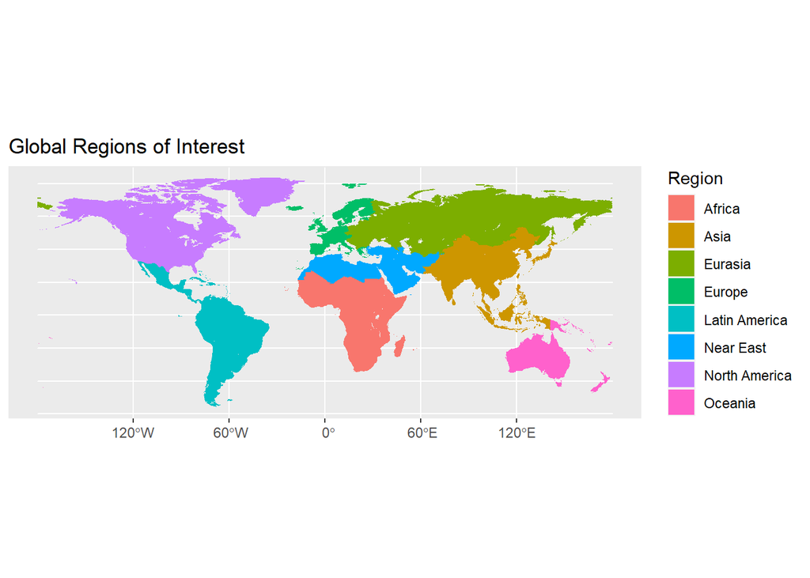

## Data Overview

The dataset that I am working with is the Anthromes dataset. It is a global land use dataset that tracks how humans have been shaping the land for the past 12,000 years. The dataset is derived from HYDE 3.2, which documents human populations and land use over time. One bias with HYDE 3.2 is that it is known to underestimate early agricultural land use. To avoid having to deal with this bias, my analysis will focus on recent history instead of prehistory.

The data is in the format of an equal-area Discrete Global Grid system (~96 square kilometer hexagonal “DGG cells”) – a total of 1,429,024 cells across the globe. The authors chose this format because it overcomes spatial biases present in previous versions of the dataset, which was formatted with non equal-area 5 arc-minute grid cells (this is also the format of the HYDE data, which it is based upon).

This is the classification scheme that the authors used to determine land use.

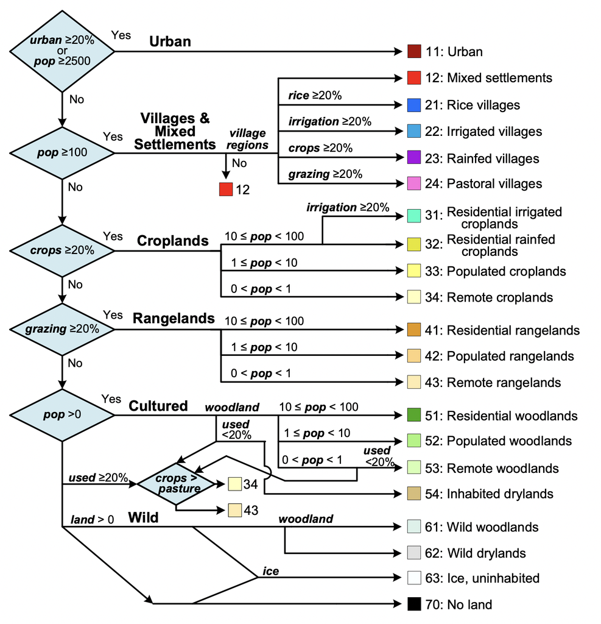

## Visualizations

This first map shows global land use in 1900 according to the classification scheme above.

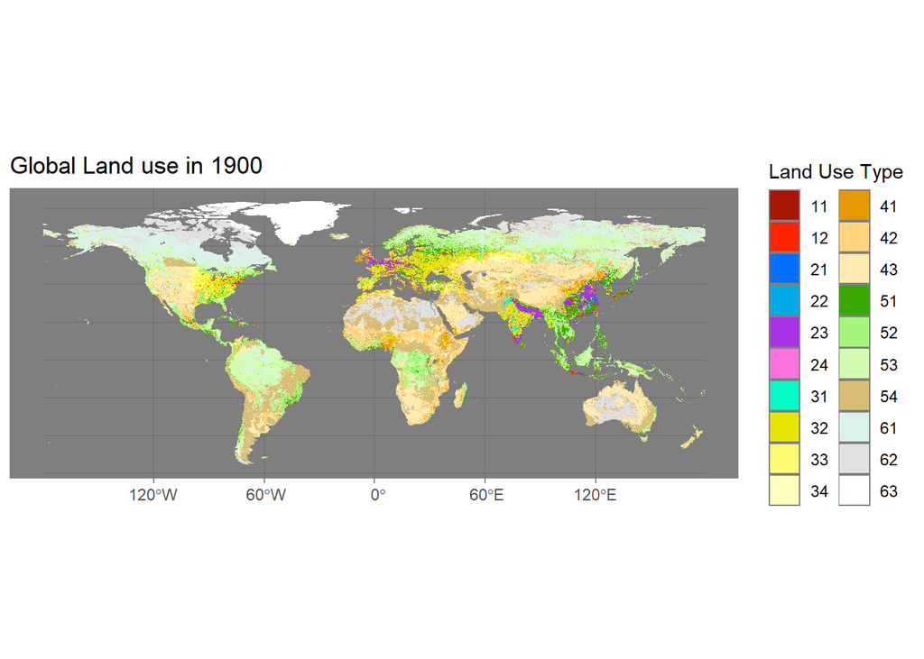

This next map shows global land use in 2000.

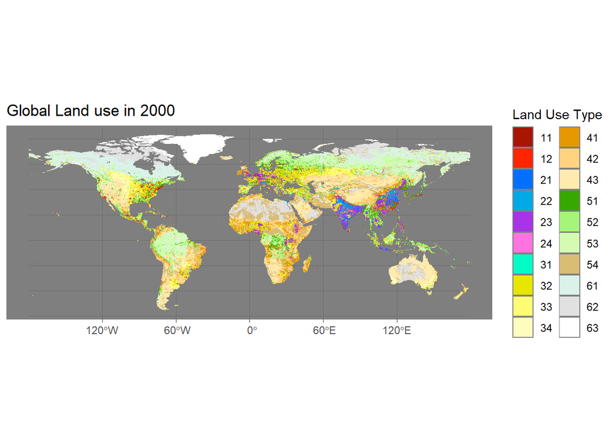

This histogram shows the distribution of land use types by region in 1900. The most common land use type in 1900 was Inhabited Drylands (54), followed by Remote Rangelands (43), and Remote Woodlands (53).

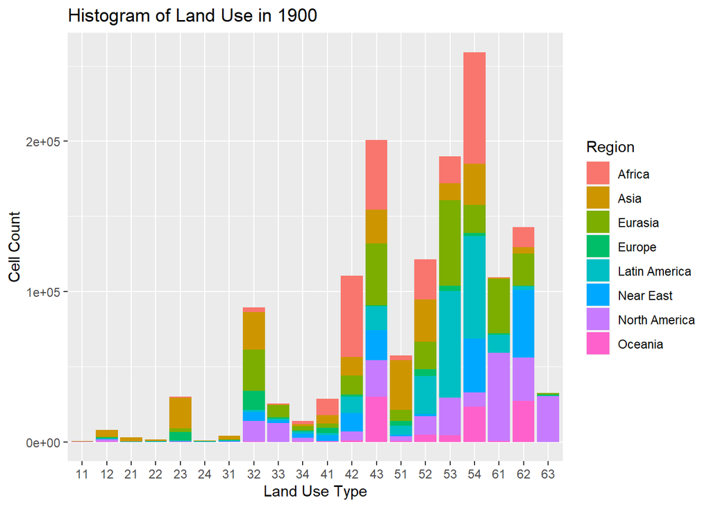

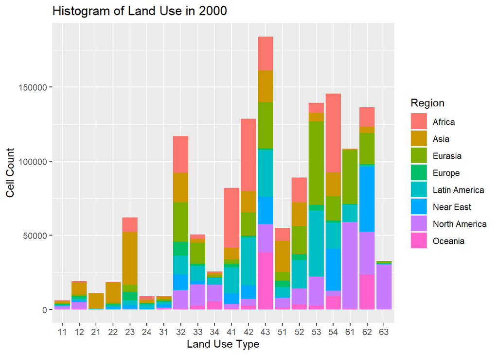

## Analysis

The first step of analysis is to reclassify the land use types into two categories: 1 for developed and 0 for not developed. Land classified as remote, wild, and unihabited will be considered not developed (with the exception of remote croplands, which will be considered developed), and everything else will be considered developed.

The reclassification is as follows:

### Developed:

- Urban – 11
- Mixed Settlements – 12
- Rice Villages – 21
- Irrigated Villages – 22
- Rainfed Villages – 23
- Pastoral Villages – 24
- Residential Irrigated Croplands – 31
- Residential Rainfed Croplands – 32
- Populated Croplands – 33
- Remote Croplands – 34
- Residential Rangelands – 41
- Populated Rangelands – 42
- Residential Woodlands – 51
- Populated Woodlands – 52
- Inhabited Drylands – 54

### Not Developed:

- Remote Rangelands – 43
- Remote Woodlands – 53
- Wild Woodlands – 61
- Wild Drylands – 62
- Ice, Uninhabited – 63

### Maps of Reclassified Data

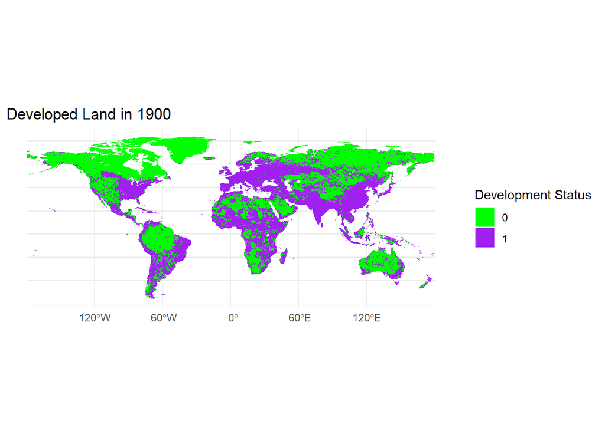

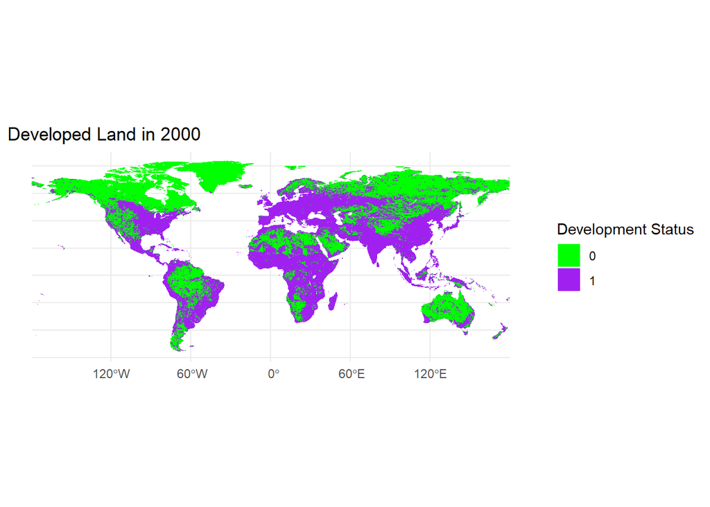

### Cluster Analysis

Now that the data is reclassified, a cluster analysis can be performed. A local Moran’s I test will reveal the level of spatial autocorrelation at a local level, which will give insight into which areas are statistically significantly clustered or not.

Unfortunately, due to the large size of the global data set, computation times were taking over an hour without finishing. Because of this, I had to subset the data to the North American region.

Additionally, the analysis only consists of 50 repetitions, where the default for a test like this is 999. Less repetitions means less significant results. In this case, where time is a constraint, only 50 repetitions on a subset of the data will have to suffice.

In the future, on a machine with more computational power, I hope to repeat the analysis on the global dataset with a large number of repetitions.

For now, the results of the North American hotspot analysis are still interesting! “Hot” areas signify where high value cells (cells with a value of 1, developed) are statistically more likely to be next to other high value cells. The “Cold” areas signify where low value cells (0, not developed) are statistically more likely to be next to other low value cells. The “Insignificant” cells do not display spatial autocorrelation.

### Hotspots in North America in 1900

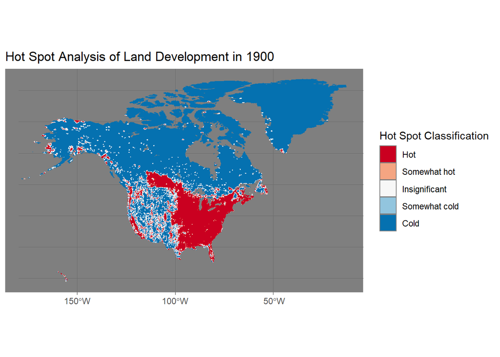

Interpretation: These results show that the entire east coast of the United states as hot spots for development. This is not surprising. There has been a lot of human impact in this area. Also not surprising is that the cold spots are covering areas of ice and boreal forest. These are not lands that are typically useful for humans to develop, so they are left natural. There is a very small amount of cells with the in-between classifications. I wonder if this is a product of having a small number of repetitions, or if this pattern would remain the same in a test with 999 repetitions.

### Hotspots in North America in 2000

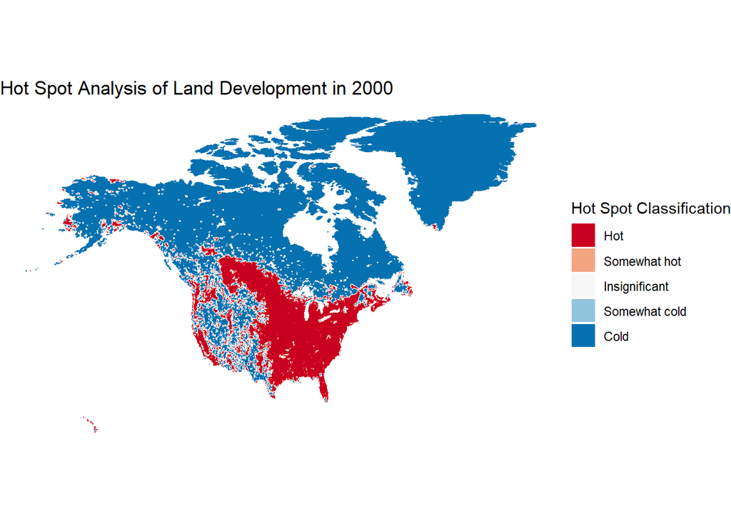

Interpretation: The hot areas have expanded westward in the United States, and have grown in size in Canada. In general, the hot areas expanded. This expansion of human influence into undeveloped areas is consistent with what would be expected.

### Concluding Thoughts

The results of the cluster analysis show that over the past century, humans have increased the amount of developed land in North America. A possible explanation for areas that remain undeveloped is that they are not economically useful to develop, like ice. As long as there is wild land left that could become useful to humans, one could assume that it will eventually be subject to direct human influence.

## References

Ellis, Erle; Nicolas Gauthier, 2023, “Anthromes 12K DGG v1 shapefile”, https://doi.org/10.7910/DVN/SZFCPX, Harvard Dataverse, V1; anthromes_12k_dgg_v1_complete.zip

Hotspot Analysis Tutorial by Heatherlee Leary. Link: https://rpubs.com/heatherleeleary/hotspot_getisOrd_tut